# Nature Climate Change paper results

Lou Carr-Harris

2025-10-14

## Bottom temperatures

### Historical by decade and projected

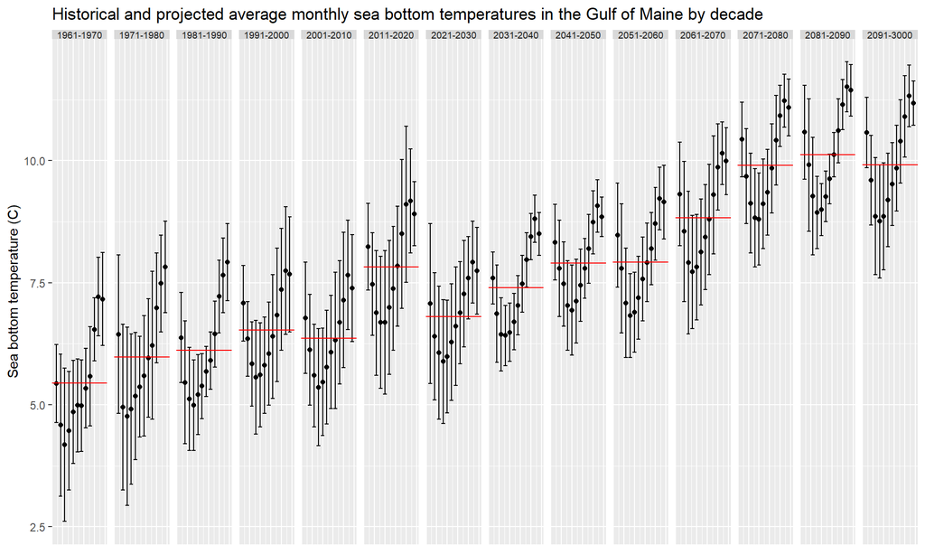

*Mean monthly bottom temps by decade/year, red line indicates the decadal average. Bars represent mean monthly temp +/- 1.96 x standard dev.*

### Projected

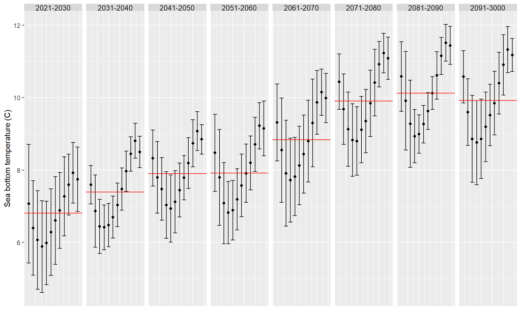

*Mean monthly bottom temps by decade/year, red line indicates the decadal average. Bars represent mean monthly temp +/- 1.96 x standard dev.*

### Historical by year and projected

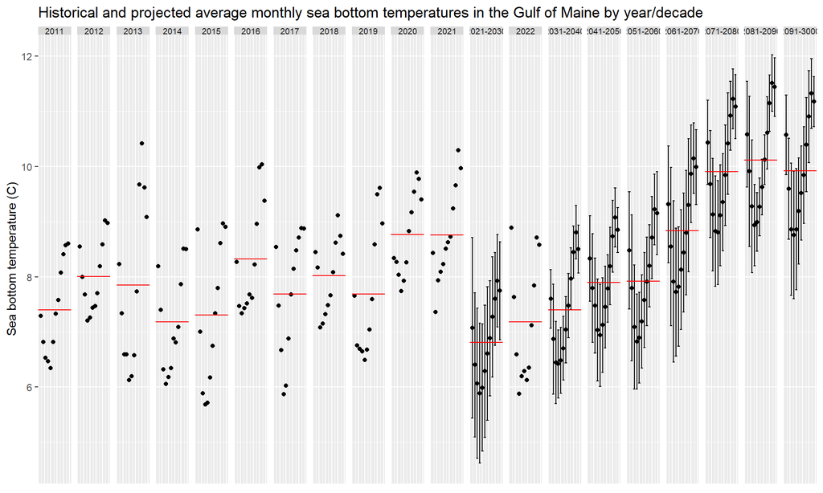

## Regulations, effort by state and year

### Directed trips

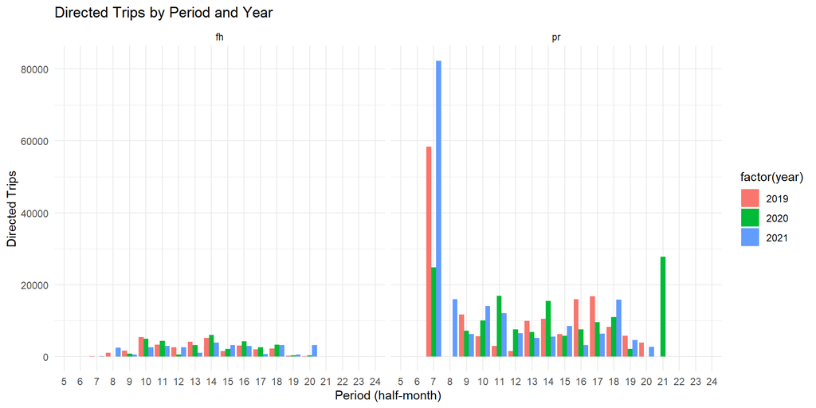

### Haddock bag limits

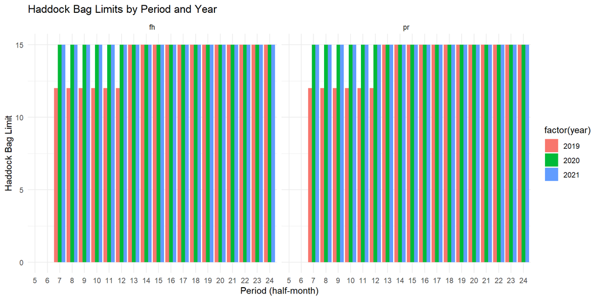

### Cod bag limits

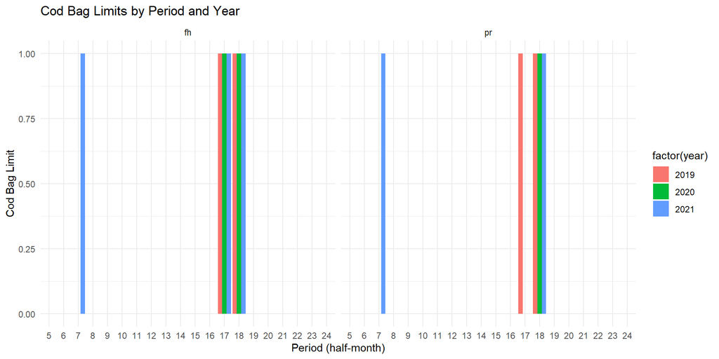

### Directed trips by state

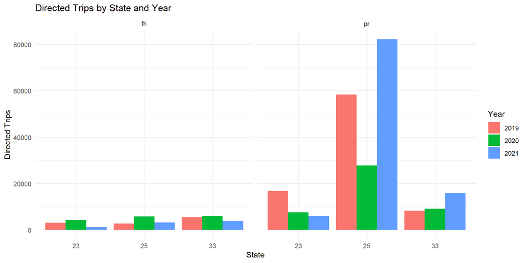

### Directed trips by period and cod open status

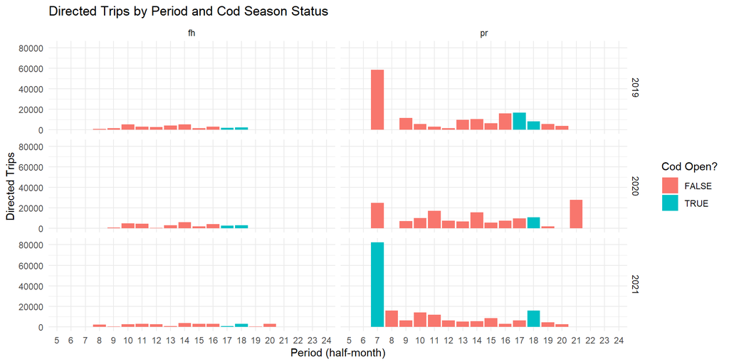

## Welfare loss from full closures, by year

### Cod closure

Total CV from closing cod, by year

| year | mean_cv | sd_cv |
| --- | --- | --- |
| 2019 | 995,195 | 75,097 |
| 2020 | 416,734 | 59,952 |
| 2021 | 5,667,968 | 331,601 |

### Cod and haddock closure

Total CV from closing both fisheries, by year

| year | mean_cv | sd_cv |
| --- | --- | --- |
| 2019 | 27,239,852 | 442,188 |
| 2020 | 28,334,349 | 334,674 |
| 2021 | 30,088,380 | 502,172 |

## Coastwide decadal projections - welfare

Each tab contains different projected fishery outcomes across copula models for the case of dependence, independence, and the difference between dependence and independence. Projected catch-per-trip data from 2025-09-18.

### CV per trip

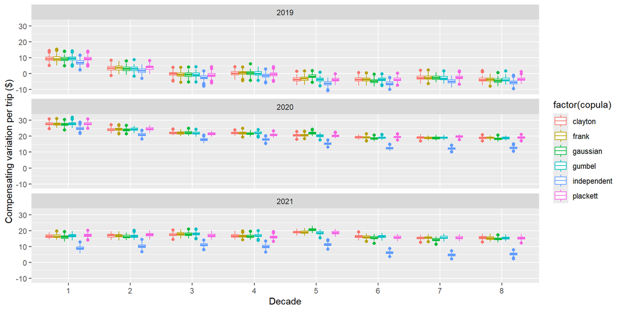

### Difference in CV per trip (corr. - ind.)

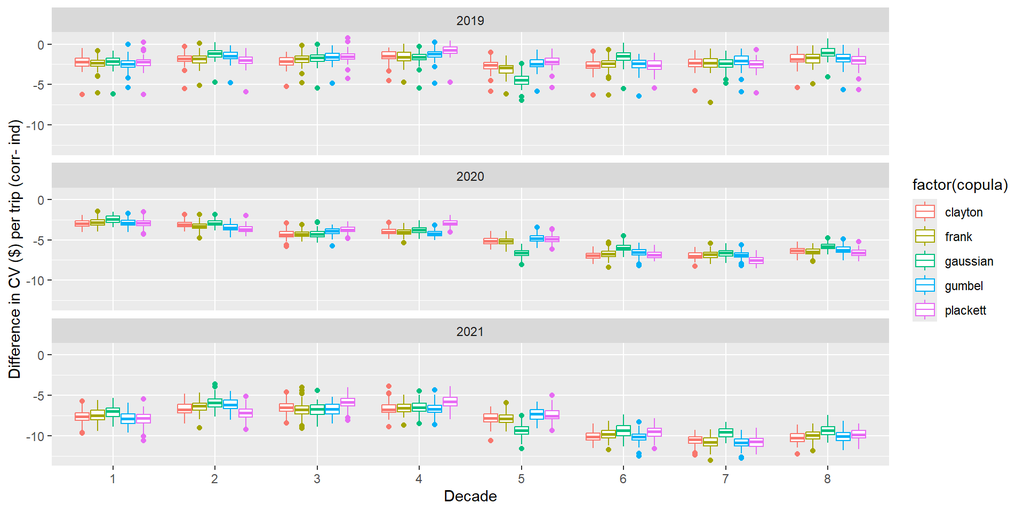

### CV per choice occasion

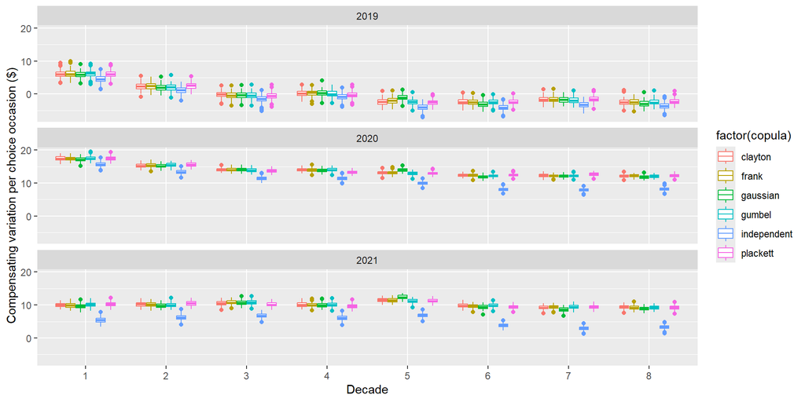

### Difference in CV per choice occasion (corr. - ind.)

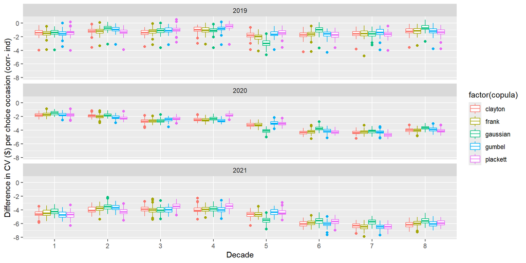

### Total CV

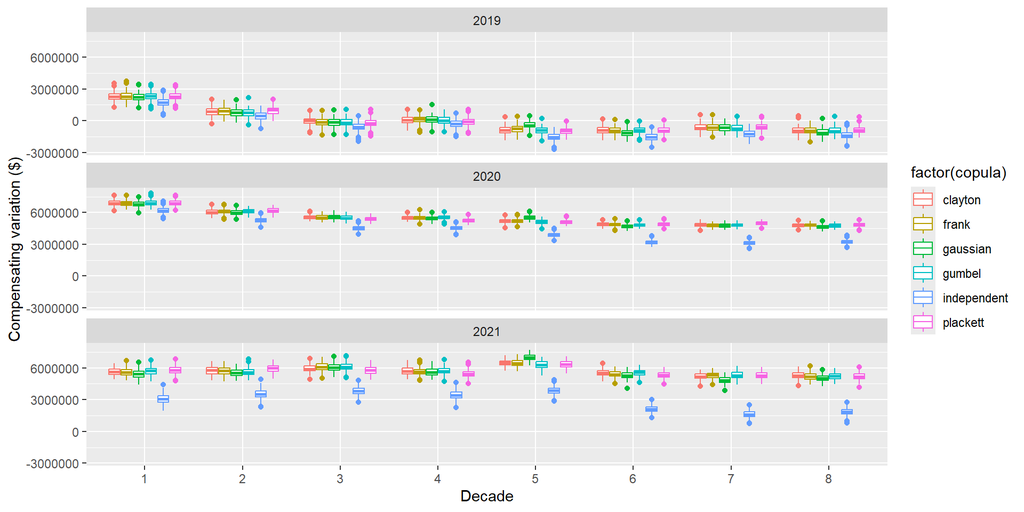

### Total CV as % of total value

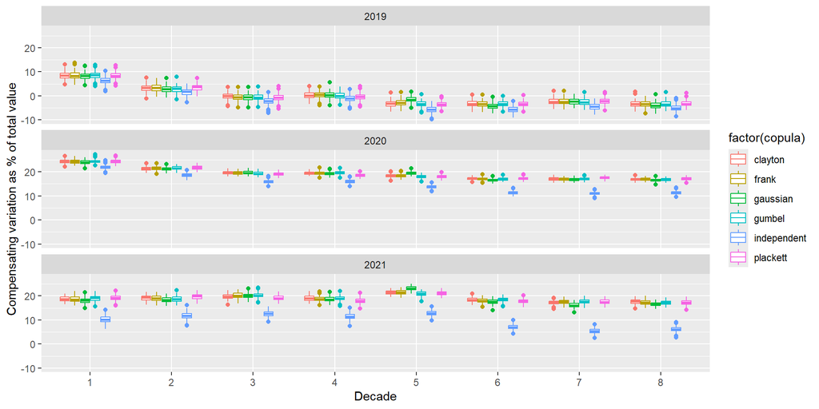

### Difference in total CV (corr. - ind.)

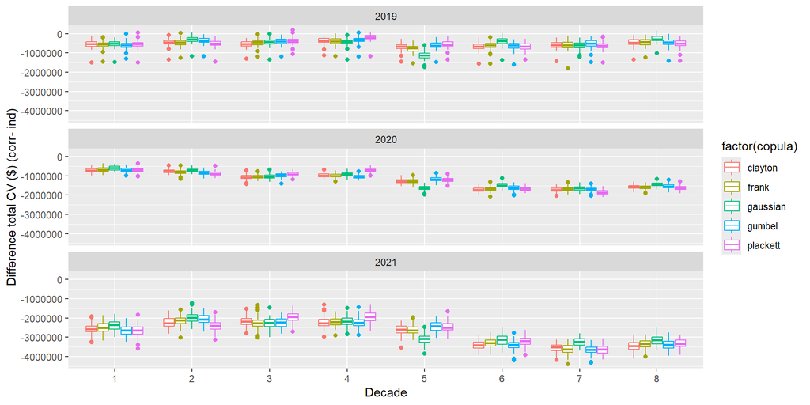

### Total directed trips

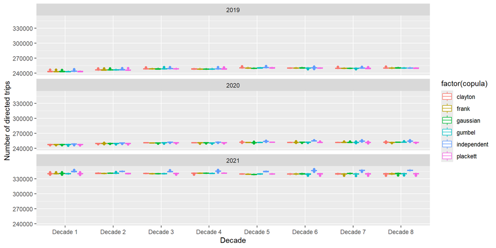

### Difference in total directed trips (corr. - ind.)

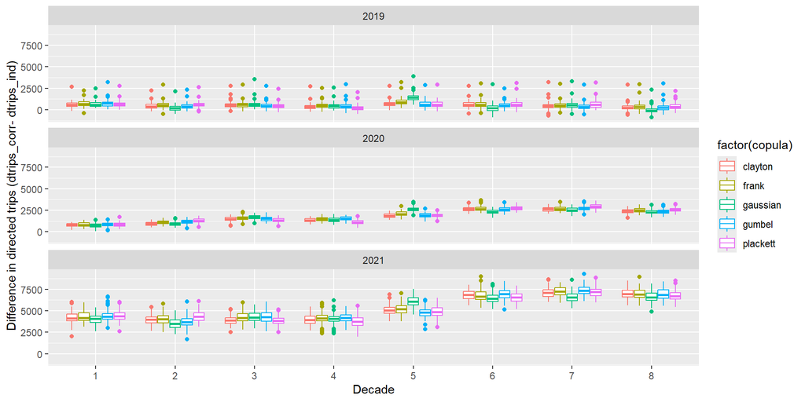

## Coastwide decadal projections - catch outcomes at the trip level

Projected catch-per-trip data from 2025-09-18.

### cod catch per trip

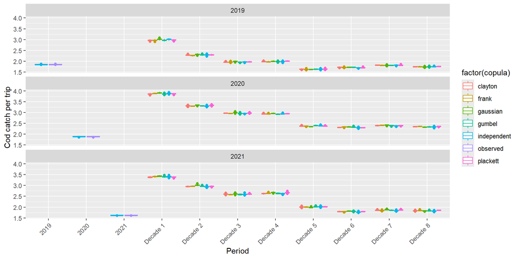

### cod keep per trip

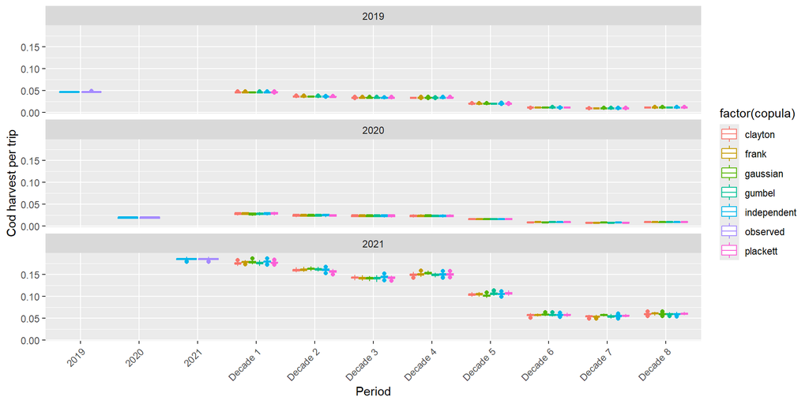

### cod release per trip

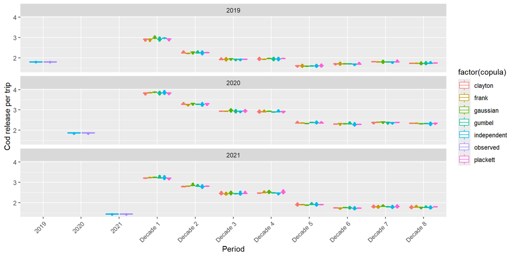

### haddock catch per trip

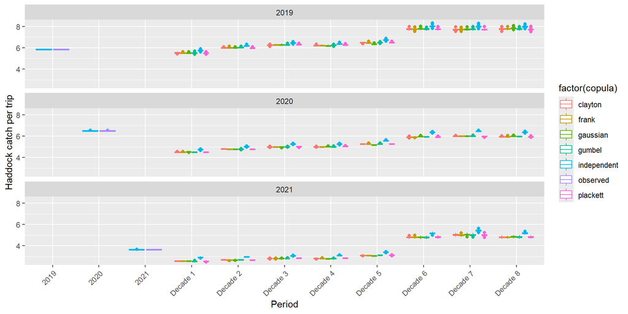

### haddock keep per trip

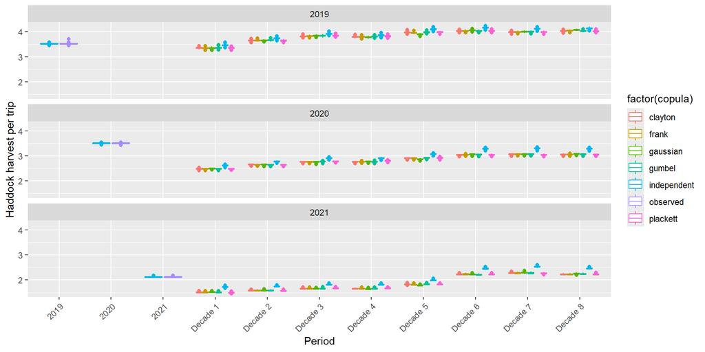

### haddock release per trip

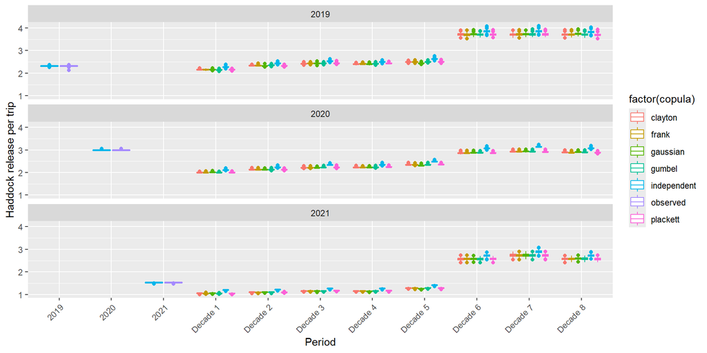

### k-tau catch

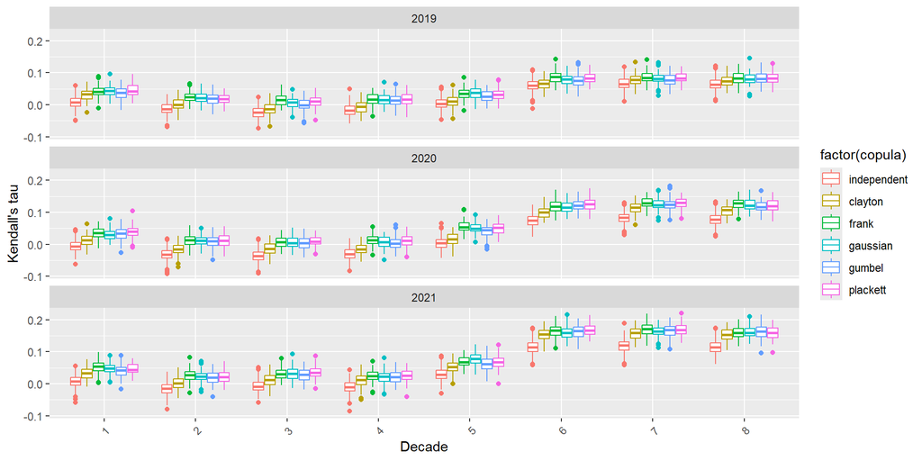

### k-tau keep

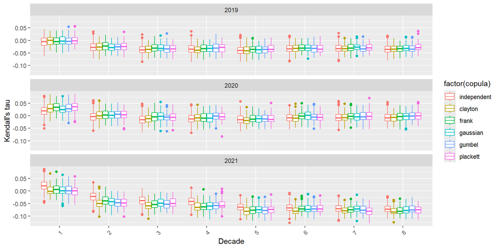

## Coastwide decadal projections - % of trips with catch of both species above/below X percentile

### above 10th

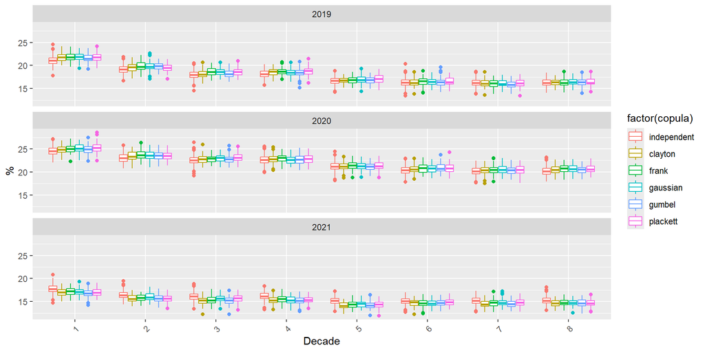

### above 25th

[figure not shown]

### above 50th

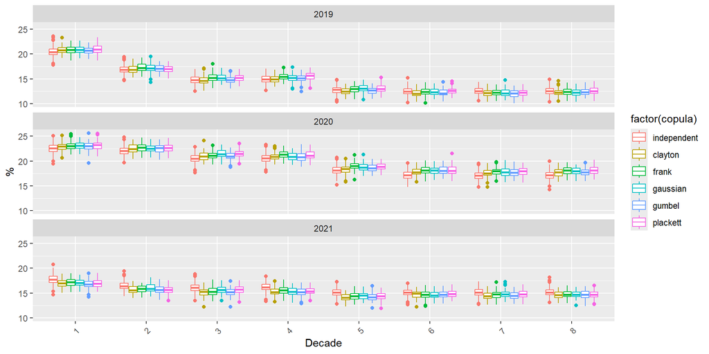

### above 75th

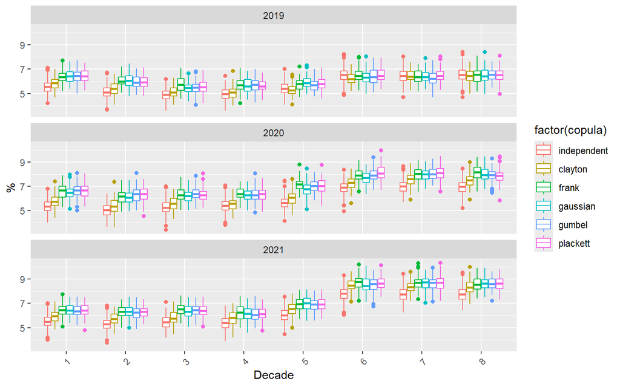

### above 90th

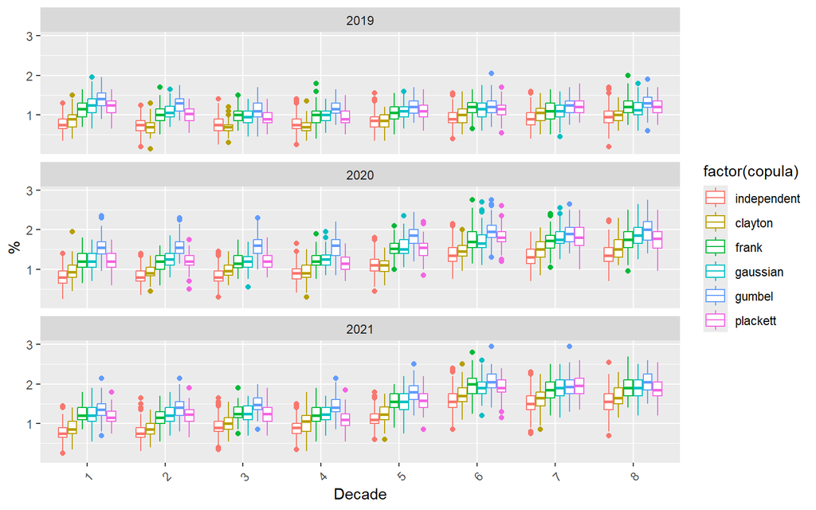

### below 10th

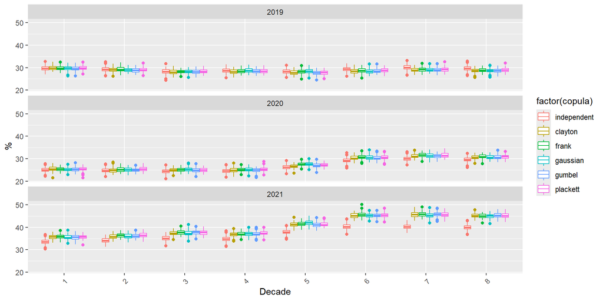

### below 25th

[figure not shown]